# Risk Factor Analysis

## Outcome Variable

**Outcome Variable:** ever_swasted

## Predictor Variables

**Intervention Variable:** meducyrs

**Adjustment Set:**

unadjusted

## Stratifying Variables

The analysis was stratified on these variable(s):

- agecat
- studyid
- country

## Data Summary

| agecat | studyid | country | meducyrs | ever_swasted | n_cell | n | outcome_variable |
| --- | --- | --- | --- | --- | --- | --- | --- |
| 0-24 months | ki0047075b-MAL-ED | BANGLADESH | High | 0 | 74 | 213 | ever_swasted |
| 0-24 months | ki0047075b-MAL-ED | BANGLADESH | High | 1 | 4 | 213 | ever_swasted |
| 0-24 months | ki0047075b-MAL-ED | BANGLADESH | Low | 0 | 63 | 213 | ever_swasted |
| 0-24 months | ki0047075b-MAL-ED | BANGLADESH | Low | 1 | 7 | 213 | ever_swasted |
| 0-24 months | ki0047075b-MAL-ED | BANGLADESH | Medium | 0 | 61 | 213 | ever_swasted |
| 0-24 months | ki0047075b-MAL-ED | BANGLADESH | Medium | 1 | 4 | 213 | ever_swasted |
| 0-24 months | ki0047075b-MAL-ED | BRAZIL | High | 0 | 77 | 232 | ever_swasted |
| 0-24 months | ki0047075b-MAL-ED | BRAZIL | High | 1 | 2 | 232 | ever_swasted |
| 0-24 months | ki0047075b-MAL-ED | BRAZIL | Low | 0 | 62 | 232 | ever_swasted |
| 0-24 months | ki0047075b-MAL-ED | BRAZIL | Low | 1 | 1 | 232 | ever_swasted |
| 0-24 months | ki0047075b-MAL-ED | BRAZIL | Medium | 0 | 89 | 232 | ever_swasted |
| 0-24 months | ki0047075b-MAL-ED | BRAZIL | Medium | 1 | 1 | 232 | ever_swasted |
| 0-24 months | ki0047075b-MAL-ED | INDIA | High | 0 | 57 | 220 | ever_swasted |
| 0-24 months | ki0047075b-MAL-ED | INDIA | High | 1 | 6 | 220 | ever_swasted |
| 0-24 months | ki0047075b-MAL-ED | INDIA | Low | 0 | 68 | 220 | ever_swasted |
| 0-24 months | ki0047075b-MAL-ED | INDIA | Low | 1 | 8 | 220 | ever_swasted |
| 0-24 months | ki0047075b-MAL-ED | INDIA | Medium | 0 | 73 | 220 | ever_swasted |
| 0-24 months | ki0047075b-MAL-ED | INDIA | Medium | 1 | 8 | 220 | ever_swasted |
| 0-24 months | ki0047075b-MAL-ED | NEPAL | High | 0 | 52 | 225 | ever_swasted |
| 0-24 months | ki0047075b-MAL-ED | NEPAL | High | 1 | 1 | 225 | ever_swasted |
| 0-24 months | ki0047075b-MAL-ED | NEPAL | Low | 0 | 93 | 225 | ever_swasted |
| 0-24 months | ki0047075b-MAL-ED | NEPAL | Low | 1 | 3 | 225 | ever_swasted |
| 0-24 months | ki0047075b-MAL-ED | NEPAL | Medium | 0 | 73 | 225 | ever_swasted |
| 0-24 months | ki0047075b-MAL-ED | NEPAL | Medium | 1 | 3 | 225 | ever_swasted |
| 0-24 months | ki0047075b-MAL-ED | PERU | High | 0 | 90 | 301 | ever_swasted |
| 0-24 months | ki0047075b-MAL-ED | PERU | High | 1 | 0 | 301 | ever_swasted |
| 0-24 months | ki0047075b-MAL-ED | PERU | Low | 0 | 101 | 301 | ever_swasted |
| 0-24 months | ki0047075b-MAL-ED | PERU | Low | 1 | 3 | 301 | ever_swasted |
| 0-24 months | ki0047075b-MAL-ED | PERU | Medium | 0 | 106 | 301 | ever_swasted |
| 0-24 months | ki0047075b-MAL-ED | PERU | Medium | 1 | 1 | 301 | ever_swasted |

[output cut: 438 more lines]

The following strata were considered:

- agecat: 0-24 months, studyid: ki0047075b-MAL-ED, country: BANGLADESH
- agecat: 0-24 months, studyid: ki0047075b-MAL-ED, country: BRAZIL
- agecat: 0-24 months, studyid: ki0047075b-MAL-ED, country: INDIA
- agecat: 0-24 months, studyid: ki0047075b-MAL-ED, country: NEPAL
- agecat: 0-24 months, studyid: ki0047075b-MAL-ED, country: PERU
- agecat: 0-24 months, studyid: ki0047075b-MAL-ED, country: SOUTH AFRICA
- agecat: 0-24 months, studyid: ki0047075b-MAL-ED, country: TANZANIA, UNITED REPUBLIC OF
- agecat: 0-24 months, studyid: ki1000108-CMC-V-BCS-2002, country: INDIA
- agecat: 0-24 months, studyid: ki1000108-IRC, country: INDIA
- agecat: 0-24 months, studyid: ki1000109-EE, country: PAKISTAN
- agecat: 0-24 months, studyid: ki1000304b-SAS-CompFeed, country: INDIA
- agecat: 0-24 months, studyid: ki1000304b-SAS-FoodSuppl, country: INDIA
- agecat: 0-24 months, studyid: ki1017093-NIH-Birth, country: BANGLADESH
- agecat: 0-24 months, studyid: ki1017093b-PROVIDE, country: BANGLADESH
- agecat: 0-24 months, studyid: ki1017093c-NIH-Crypto, country: BANGLADESH
- agecat: 0-24 months, studyid: ki1066203-TanzaniaChild2, country: TANZANIA, UNITED REPUBLIC OF
- agecat: 0-24 months, studyid: ki1112895-Guatemala BSC, country: GUATEMALA
- agecat: 0-24 months, studyid: ki1113344-GMS-Nepal, country: NEPAL
- agecat: 0-24 months, studyid: ki1119695-PROBIT, country: BELARUS
- agecat: 0-24 months, studyid: ki1126311-ZVITAMBO, country: ZIMBABWE
- agecat: 0-24 months, studyid: ki1135781-COHORTS, country: GUATEMALA
- agecat: 0-24 months, studyid: ki1135781-COHORTS, country: INDIA
- agecat: 0-24 months, studyid: ki1135781-COHORTS, country: PHILIPPINES
- agecat: 0-24 months, studyid: ki1148112-LCNI-5, country: MALAWI
- agecat: 0-24 months, studyid: kiGH5241-JiVitA-3, country: BANGLADESH
- agecat: 0-24 months, studyid: kiGH5241-JiVitA-4, country: BANGLADESH
- agecat: 0-6 months, studyid: ki0047075b-MAL-ED, country: BANGLADESH
- agecat: 0-6 months, studyid: ki0047075b-MAL-ED, country: BRAZIL
- agecat: 0-6 months, studyid: ki0047075b-MAL-ED, country: INDIA
- agecat: 0-6 months, studyid: ki0047075b-MAL-ED, country: NEPAL
- agecat: 0-6 months, studyid: ki0047075b-MAL-ED, country: PERU
- agecat: 0-6 months, studyid: ki0047075b-MAL-ED, country: SOUTH AFRICA
- agecat: 0-6 months, studyid: ki0047075b-MAL-ED, country: TANZANIA, UNITED REPUBLIC OF
- agecat: 0-6 months, studyid: ki1000108-CMC-V-BCS-2002, country: INDIA
- agecat: 0-6 months, studyid: ki1000108-IRC, country: INDIA
- agecat: 0-6 months, studyid: ki1000109-EE, country: PAKISTAN
- agecat: 0-6 months, studyid: ki1000304b-SAS-CompFeed, country: INDIA
- agecat: 0-6 months, studyid: ki1000304b-SAS-FoodSuppl, country: INDIA
- agecat: 0-6 months, studyid: ki1017093-NIH-Birth, country: BANGLADESH
- agecat: 0-6 months, studyid: ki1017093b-PROVIDE, country: BANGLADESH
- agecat: 0-6 months, studyid: ki1017093c-NIH-Crypto, country: BANGLADESH
- agecat: 0-6 months, studyid: ki1066203-TanzaniaChild2, country: TANZANIA, UNITED REPUBLIC OF
- agecat: 0-6 months, studyid: ki1112895-Guatemala BSC, country: GUATEMALA
- agecat: 0-6 months, studyid: ki1113344-GMS-Nepal, country: NEPAL
- agecat: 0-6 months, studyid: ki1119695-PROBIT, country: BELARUS
- agecat: 0-6 months, studyid: ki1126311-ZVITAMBO, country: ZIMBABWE
- agecat: 0-6 months, studyid: ki1135781-COHORTS, country: GUATEMALA
- agecat: 0-6 months, studyid: ki1135781-COHORTS, country: INDIA
- agecat: 0-6 months, studyid: ki1135781-COHORTS, country: PHILIPPINES
- agecat: 0-6 months, studyid: ki1148112-LCNI-5, country: MALAWI
- agecat: 0-6 months, studyid: kiGH5241-JiVitA-3, country: BANGLADESH
- agecat: 0-6 months, studyid: kiGH5241-JiVitA-4, country: BANGLADESH
- agecat: 6-24 months, studyid: ki0047075b-MAL-ED, country: BANGLADESH
- agecat: 6-24 months, studyid: ki0047075b-MAL-ED, country: BRAZIL
- agecat: 6-24 months, studyid: ki0047075b-MAL-ED, country: INDIA
- agecat: 6-24 months, studyid: ki0047075b-MAL-ED, country: NEPAL
- agecat: 6-24 months, studyid: ki0047075b-MAL-ED, country: PERU
- agecat: 6-24 months, studyid: ki0047075b-MAL-ED, country: SOUTH AFRICA
- agecat: 6-24 months, studyid: ki0047075b-MAL-ED, country: TANZANIA, UNITED REPUBLIC OF
- agecat: 6-24 months, studyid: ki1000108-CMC-V-BCS-2002, country: INDIA
- agecat: 6-24 months, studyid: ki1000108-IRC, country: INDIA
- agecat: 6-24 months, studyid: ki1000109-EE, country: PAKISTAN
- agecat: 6-24 months, studyid: ki1000304b-SAS-CompFeed, country: INDIA
- agecat: 6-24 months, studyid: ki1000304b-SAS-FoodSuppl, country: INDIA
- agecat: 6-24 months, studyid: ki1017093-NIH-Birth, country: BANGLADESH
- agecat: 6-24 months, studyid: ki1017093b-PROVIDE, country: BANGLADESH
- agecat: 6-24 months, studyid: ki1017093c-NIH-Crypto, country: BANGLADESH
- agecat: 6-24 months, studyid: ki1066203-TanzaniaChild2, country: TANZANIA, UNITED REPUBLIC OF
- agecat: 6-24 months, studyid: ki1112895-Guatemala BSC, country: GUATEMALA
- agecat: 6-24 months, studyid: ki1113344-GMS-Nepal, country: NEPAL
- agecat: 6-24 months, studyid: ki1119695-PROBIT, country: BELARUS
- agecat: 6-24 months, studyid: ki1126311-ZVITAMBO, country: ZIMBABWE
- agecat: 6-24 months, studyid: ki1135781-COHORTS, country: GUATEMALA
- agecat: 6-24 months, studyid: ki1135781-COHORTS, country: INDIA
- agecat: 6-24 months, studyid: ki1135781-COHORTS, country: PHILIPPINES
- agecat: 6-24 months, studyid: ki1148112-LCNI-5, country: MALAWI
- agecat: 6-24 months, studyid: kiGH5241-JiVitA-3, country: BANGLADESH
- agecat: 6-24 months, studyid: kiGH5241-JiVitA-4, country: BANGLADESH

### Dropped Strata

Some strata were dropped due to rare outcomes:

- agecat: 0-24 months, studyid: ki0047075b-MAL-ED, country: BANGLADESH
- agecat: 0-24 months, studyid: ki0047075b-MAL-ED, country: BRAZIL
- agecat: 0-24 months, studyid: ki0047075b-MAL-ED, country: NEPAL
- agecat: 0-24 months, studyid: ki0047075b-MAL-ED, country: PERU
- agecat: 0-24 months, studyid: ki0047075b-MAL-ED, country: SOUTH AFRICA
- agecat: 0-24 months, studyid: ki0047075b-MAL-ED, country: TANZANIA, UNITED REPUBLIC OF
- agecat: 0-24 months, studyid: ki1000109-EE, country: PAKISTAN
- agecat: 0-24 months, studyid: ki1000304b-SAS-FoodSuppl, country: INDIA
- agecat: 0-24 months, studyid: ki1112895-Guatemala BSC, country: GUATEMALA
- agecat: 0-24 months, studyid: ki1148112-LCNI-5, country: MALAWI
- agecat: 0-6 months, studyid: ki0047075b-MAL-ED, country: BANGLADESH
- agecat: 0-6 months, studyid: ki0047075b-MAL-ED, country: BRAZIL
- agecat: 0-6 months, studyid: ki0047075b-MAL-ED, country: INDIA
- agecat: 0-6 months, studyid: ki0047075b-MAL-ED, country: NEPAL
- agecat: 0-6 months, studyid: ki0047075b-MAL-ED, country: PERU
- agecat: 0-6 months, studyid: ki0047075b-MAL-ED, country: SOUTH AFRICA
- agecat: 0-6 months, studyid: ki0047075b-MAL-ED, country: TANZANIA, UNITED REPUBLIC OF
- agecat: 0-6 months, studyid: ki1000109-EE, country: PAKISTAN
- agecat: 0-6 months, studyid: ki1000304b-SAS-FoodSuppl, country: INDIA
- agecat: 0-6 months, studyid: ki1066203-TanzaniaChild2, country: TANZANIA, UNITED REPUBLIC OF
- agecat: 0-6 months, studyid: ki1112895-Guatemala BSC, country: GUATEMALA
- agecat: 0-6 months, studyid: ki1148112-LCNI-5, country: MALAWI
- agecat: 6-24 months, studyid: ki0047075b-MAL-ED, country: BANGLADESH
- agecat: 6-24 months, studyid: ki0047075b-MAL-ED, country: BRAZIL
- agecat: 6-24 months, studyid: ki0047075b-MAL-ED, country: INDIA
- agecat: 6-24 months, studyid: ki0047075b-MAL-ED, country: NEPAL
- agecat: 6-24 months, studyid: ki0047075b-MAL-ED, country: PERU
- agecat: 6-24 months, studyid: ki0047075b-MAL-ED, country: SOUTH AFRICA
- agecat: 6-24 months, studyid: ki0047075b-MAL-ED, country: TANZANIA, UNITED REPUBLIC OF
- agecat: 6-24 months, studyid: ki1000109-EE, country: PAKISTAN
- agecat: 6-24 months, studyid: ki1000304b-SAS-FoodSuppl, country: INDIA
- agecat: 6-24 months, studyid: ki1017093b-PROVIDE, country: BANGLADESH
- agecat: 6-24 months, studyid: ki1017093c-NIH-Crypto, country: BANGLADESH
- agecat: 6-24 months, studyid: ki1112895-Guatemala BSC, country: GUATEMALA
- agecat: 6-24 months, studyid: ki1119695-PROBIT, country: BELARUS
- agecat: 6-24 months, studyid: ki1148112-LCNI-5, country: MALAWI

## Methods Detail

We’re interested in the causal parameters $E[Y_a]$ for all values of $a \in \mathcal{A}$. These parameters represent the mean outcome if, possibly contrary to fact, we intervened to set all units to have $A=a$. Under the randomization and positivity assumptions, these are identified by the statistical parameters $\psi_a=E_W[E_{Y|A,W}(Y|A=a,W)]$. In addition, we’re interested in the mean of $Y$, $E[Y]$ under no intervention (the observed mean). We will estimate these parameters by using SuperLearner to fit the relevant likelihood factors – $E_{Y|A,W}(Y|A=a,W)$ and $p(A=a|W)$, and then updating our likelihood fit using a joint TMLE.

For unadjusted analyses ($W=\{\}$), initial likelihoods were estimated using Lrnr_glm to estimate the simple $E(Y|A)$ and Lrnr_mean to estimate $p(A)$. For adjusted analyses, a small library containing Lrnr_glmnet, Lrnr_xgboost, and Lrnr_mean was used.

Having estimated these parameters, we will then use the delta method to estimate relative risks and attributable risks relative to a prespecified baseline level of $A$.

# Results Detail

## Results Plots

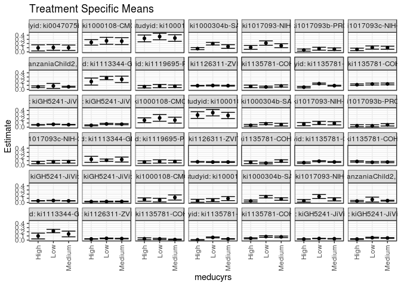

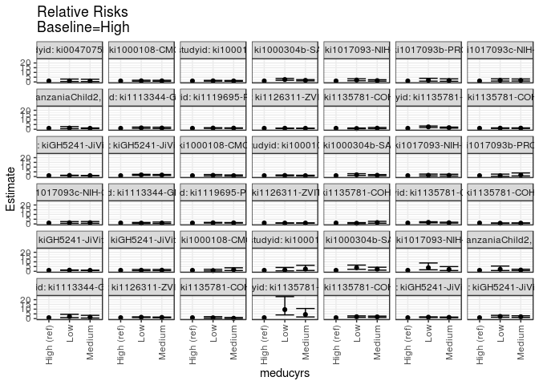

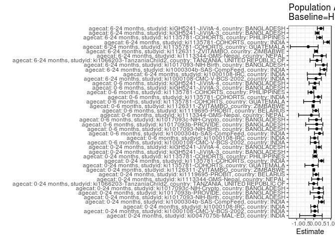

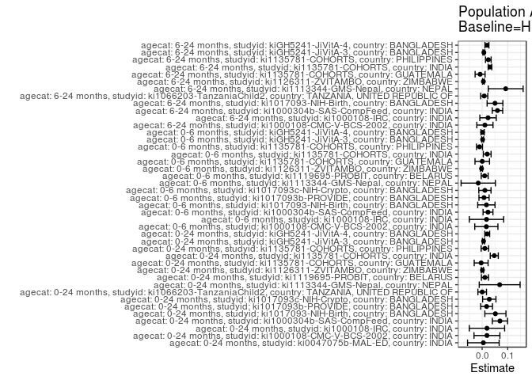

## Results Table

### Parameter: TSM

| agecat | studyid | country | intervention_level | baseline_level | estimate | ci_lower | ci_upper |
| --- | --- | --- | --- | --- | --- | --- | --- |
| 0-24 months | ki0047075b-MAL-ED | INDIA | High | NA | 0.0952381 | 0.0225874 | 0.1678888 |
| 0-24 months | ki0047075b-MAL-ED | INDIA | Low | NA | 0.1052632 | 0.0361093 | 0.1744170 |
| 0-24 months | ki0047075b-MAL-ED | INDIA | Medium | NA | 0.0987654 | 0.0336452 | 0.1638857 |
| 0-24 months | ki1000108-CMC-V-BCS-2002 | INDIA | High | NA | 0.2278481 | 0.1623579 | 0.2933383 |
| 0-24 months | ki1000108-CMC-V-BCS-2002 | INDIA | Low | NA | 0.2641509 | 0.1801085 | 0.3481934 |
| 0-24 months | ki1000108-CMC-V-BCS-2002 | INDIA | Medium | NA | 0.2568807 | 0.1747487 | 0.3390128 |
| 0-24 months | ki1000108-IRC | INDIA | High | NA | 0.3225806 | 0.2402018 | 0.4049594 |
| 0-24 months | ki1000108-IRC | INDIA | Low | NA | 0.3673469 | 0.2893207 | 0.4453732 |
| 0-24 months | ki1000108-IRC | INDIA | Medium | NA | 0.3309353 | 0.2526146 | 0.4092560 |
| 0-24 months | ki1000304b-SAS-CompFeed | INDIA | High | NA | 0.0776398 | 0.0519187 | 0.1033608 |
| 0-24 months | ki1000304b-SAS-CompFeed | INDIA | Low | NA | 0.1950147 | 0.1641915 | 0.2258379 |
| 0-24 months | ki1000304b-SAS-CompFeed | INDIA | Medium | NA | 0.1277014 | 0.0829171 | 0.1724857 |
| 0-24 months | ki1017093-NIH-Birth | BANGLADESH | High | NA | 0.1067416 | 0.0613431 | 0.1521401 |
| 0-24 months | ki1017093-NIH-Birth | BANGLADESH | Low | NA | 0.2105263 | 0.1575660 | 0.2634867 |
| 0-24 months | ki1017093-NIH-Birth | BANGLADESH | Medium | NA | 0.1467890 | 0.0997733 | 0.1938047 |
| 0-24 months | ki1017093b-PROVIDE | BANGLADESH | High | NA | 0.0425532 | 0.0167277 | 0.0683786 |
| 0-24 months | ki1017093b-PROVIDE | BANGLADESH | Low | NA | 0.0747664 | 0.0395024 | 0.1100303 |
| 0-24 months | ki1017093b-PROVIDE | BANGLADESH | Medium | NA | 0.0637450 | 0.0335008 | 0.0939892 |
| 0-24 months | ki1017093c-NIH-Crypto | BANGLADESH | High | NA | 0.0590551 | 0.0300464 | 0.0880639 |
| 0-24 months | ki1017093c-NIH-Crypto | BANGLADESH | Low | NA | 0.1033058 | 0.0649340 | 0.1416775 |
| 0-24 months | ki1017093c-NIH-Crypto | BANGLADESH | Medium | NA | 0.0992366 | 0.0630102 | 0.1354631 |
| 0-24 months | ki1066203-TanzaniaChild2 | TANZANIA, UNITED REPUBLIC OF | High | NA | 0.0660225 | 0.0464878 | 0.0855573 |
| 0-24 months | ki1066203-TanzaniaChild2 | TANZANIA, UNITED REPUBLIC OF | Low | NA | 0.0853659 | 0.0248738 | 0.1458579 |
| 0-24 months | ki1066203-TanzaniaChild2 | TANZANIA, UNITED REPUBLIC OF | Medium | NA | 0.0653595 | 0.0535488 | 0.0771701 |
| 0-24 months | ki1113344-GMS-Nepal | NEPAL | High | NA | 0.1904762 | 0.1064409 | 0.2745115 |
| 0-24 months | ki1113344-GMS-Nepal | NEPAL | Low | NA | 0.2750000 | 0.2350257 | 0.3149743 |
| 0-24 months | ki1113344-GMS-Nepal | NEPAL | Medium | NA | 0.2436975 | 0.1665066 | 0.3208884 |
| 0-24 months | ki1119695-PROBIT | BELARUS | High | NA | 0.0665259 | 0.0369091 | 0.0961427 |
| 0-24 months | ki1119695-PROBIT | BELARUS | Low | NA | 0.0819672 | 0.0430435 | 0.1208909 |
| 0-24 months | ki1119695-PROBIT | BELARUS | Medium | NA | 0.0779188 | 0.0465983 | 0.1092393 |

[output cut: 96 more lines]

### Parameter: E(Y)

| agecat | studyid | country | intervention_level | baseline_level | estimate | ci_lower | ci_upper |
| --- | --- | --- | --- | --- | --- | --- | --- |
| 0-24 months | ki0047075b-MAL-ED | INDIA | NA | NA | 0.1000000 | 0.0602674 | 0.1397326 |
| 0-24 months | ki1000108-CMC-V-BCS-2002 | INDIA | NA | NA | 0.2466488 | 0.2028447 | 0.2904529 |
| 0-24 months | ki1000108-IRC | INDIA | NA | NA | 0.3414634 | 0.2955068 | 0.3874201 |
| 0-24 months | ki1000304b-SAS-CompFeed | INDIA | NA | NA | 0.1473893 | 0.1184132 | 0.1763654 |
| 0-24 months | ki1017093-NIH-Birth | BANGLADESH | NA | NA | 0.1586538 | 0.1299648 | 0.1873429 |
| 0-24 months | ki1017093b-PROVIDE | BANGLADESH | NA | NA | 0.0600000 | 0.0423945 | 0.0776055 |
| 0-24 months | ki1017093c-NIH-Crypto | BANGLADESH | NA | NA | 0.0870712 | 0.0669870 | 0.1071555 |
| 0-24 months | ki1066203-TanzaniaChild2 | TANZANIA, UNITED REPUBLIC OF | NA | NA | 0.0662196 | 0.0562399 | 0.0761994 |
| 0-24 months | ki1113344-GMS-Nepal | NEPAL | NA | NA | 0.2591508 | 0.2262659 | 0.2920357 |
| 0-24 months | ki1119695-PROBIT | BELARUS | NA | NA | 0.0774648 | 0.0450418 | 0.1098878 |
| 0-24 months | ki1126311-ZVITAMBO | ZIMBABWE | NA | NA | 0.0922734 | 0.0874665 | 0.0970804 |
| 0-24 months | ki1135781-COHORTS | GUATEMALA | NA | NA | 0.0711044 | 0.0572455 | 0.0849633 |
| 0-24 months | ki1135781-COHORTS | INDIA | NA | NA | 0.1030116 | 0.0952175 | 0.1108057 |
| 0-24 months | ki1135781-COHORTS | PHILIPPINES | NA | NA | 0.1254516 | 0.1136848 | 0.1372183 |
| 0-24 months | kiGH5241-JiVitA-3 | BANGLADESH | NA | NA | 0.0610653 | 0.0575838 | 0.0645468 |
| 0-24 months | kiGH5241-JiVitA-4 | BANGLADESH | NA | NA | 0.0630996 | 0.0561390 | 0.0700602 |
| 0-6 months | ki1000108-CMC-V-BCS-2002 | INDIA | NA | NA | 0.1820652 | 0.1425842 | 0.2215462 |
| 0-6 months | ki1000108-IRC | INDIA | NA | NA | 0.3073171 | 0.2626027 | 0.3520314 |
| 0-6 months | ki1000304b-SAS-CompFeed | INDIA | NA | NA | 0.0664452 | 0.0425975 | 0.0902929 |
| 0-6 months | ki1017093-NIH-Birth | BANGLADESH | NA | NA | 0.0900322 | 0.0675202 | 0.1125442 |
| 0-6 months | ki1017093b-PROVIDE | BANGLADESH | NA | NA | 0.0414286 | 0.0266555 | 0.0562017 |
| 0-6 months | ki1017093c-NIH-Crypto | BANGLADESH | NA | NA | 0.0659631 | 0.0482810 | 0.0836451 |
| 0-6 months | ki1113344-GMS-Nepal | NEPAL | NA | NA | 0.1156662 | 0.0916631 | 0.1396693 |
| 0-6 months | ki1119695-PROBIT | BELARUS | NA | NA | 0.0760580 | 0.0435003 | 0.1086157 |
| 0-6 months | ki1126311-ZVITAMBO | ZIMBABWE | NA | NA | 0.0688209 | 0.0646022 | 0.0730397 |
| 0-6 months | ki1135781-COHORTS | GUATEMALA | NA | NA | 0.0608944 | 0.0464300 | 0.0753588 |
| 0-6 months | ki1135781-COHORTS | INDIA | NA | NA | 0.0718095 | 0.0650627 | 0.0785562 |
| 0-6 months | ki1135781-COHORTS | PHILIPPINES | NA | NA | 0.0693167 | 0.0602923 | 0.0783411 |
| 0-6 months | kiGH5241-JiVitA-3 | BANGLADESH | NA | NA | 0.0414166 | 0.0384340 | 0.0443992 |
| 0-6 months | kiGH5241-JiVitA-4 | BANGLADESH | NA | NA | 0.0218633 | 0.0173413 | 0.0263853 |
| 6-24 months | ki1000108-CMC-V-BCS-2002 | INDIA | NA | NA | 0.0804290 | 0.0527929 | 0.1080650 |
| 6-24 months | ki1000108-IRC | INDIA | NA | NA | 0.0634146 | 0.0397960 | 0.0870333 |
| 6-24 months | ki1000304b-SAS-CompFeed | INDIA | NA | NA | 0.0964723 | 0.0729872 | 0.1199573 |
| 6-24 months | ki1017093-NIH-Birth | BANGLADESH | NA | NA | 0.0885609 | 0.0646203 | 0.1125014 |
| 6-24 months | ki1066203-TanzaniaChild2 | TANZANIA, UNITED REPUBLIC OF | NA | NA | 0.0412730 | 0.0325768 | 0.0499692 |
| 6-24 months | ki1113344-GMS-Nepal | NEPAL | NA | NA | 0.1908007 | 0.1589868 | 0.2226146 |
| 6-24 months | ki1126311-ZVITAMBO | ZIMBABWE | NA | NA | 0.0329630 | 0.0295956 | 0.0363303 |
| 6-24 months | ki1135781-COHORTS | GUATEMALA | NA | NA | 0.0250417 | 0.0161900 | 0.0338934 |
| 6-24 months | ki1135781-COHORTS | INDIA | NA | NA | 0.0372331 | 0.0322193 | 0.0422468 |
| 6-24 months | ki1135781-COHORTS | PHILIPPINES | NA | NA | 0.0669277 | 0.0576848 | 0.0761707 |
| 6-24 months | kiGH5241-JiVitA-3 | BANGLADESH | NA | NA | 0.0319444 | 0.0290509 | 0.0348380 |
| 6-24 months | kiGH5241-JiVitA-4 | BANGLADESH | NA | NA | 0.0439439 | 0.0381166 | 0.0497712 |

### Parameter: RR

| agecat | studyid | country | intervention_level | baseline_level | estimate | ci_lower | ci_upper |
| --- | --- | --- | --- | --- | --- | --- | --- |
| 0-24 months | ki0047075b-MAL-ED | INDIA | High | High | 1.0000000 | 1.0000000 | 1.000000 |
| 0-24 months | ki0047075b-MAL-ED | INDIA | Low | High | 1.1052631 | 0.4038751 | 3.024713 |
| 0-24 months | ki0047075b-MAL-ED | INDIA | Medium | High | 1.0370370 | 0.3783556 | 2.842421 |
| 0-24 months | ki1000108-CMC-V-BCS-2002 | INDIA | High | High | 1.0000000 | 1.0000000 | 1.000000 |
| 0-24 months | ki1000108-CMC-V-BCS-2002 | INDIA | Low | High | 1.1593291 | 0.7550840 | 1.779993 |
| 0-24 months | ki1000108-CMC-V-BCS-2002 | INDIA | Medium | High | 1.1274210 | 0.7334471 | 1.733019 |
| 0-24 months | ki1000108-IRC | INDIA | High | High | 1.0000000 | 1.0000000 | 1.000000 |
| 0-24 months | ki1000108-IRC | INDIA | Low | High | 1.1387755 | 0.8169244 | 1.587429 |
| 0-24 months | ki1000108-IRC | INDIA | Medium | High | 1.0258993 | 0.7242592 | 1.453167 |
| 0-24 months | ki1000304b-SAS-CompFeed | INDIA | High | High | 1.0000000 | 1.0000000 | 1.000000 |
| 0-24 months | ki1000304b-SAS-CompFeed | INDIA | Low | High | 2.5117889 | 1.7373183 | 3.631507 |
| 0-24 months | ki1000304b-SAS-CompFeed | INDIA | Medium | High | 1.6447937 | 1.1046742 | 2.448999 |
| 0-24 months | ki1017093-NIH-Birth | BANGLADESH | High | High | 1.0000000 | 1.0000000 | 1.000000 |
| 0-24 months | ki1017093-NIH-Birth | BANGLADESH | Low | High | 1.9722992 | 1.2032910 | 3.232771 |
| 0-24 months | ki1017093-NIH-Birth | BANGLADESH | Medium | High | 1.3751811 | 0.8074757 | 2.342019 |
| 0-24 months | ki1017093b-PROVIDE | BANGLADESH | High | High | 1.0000000 | 1.0000000 | 1.000000 |
| 0-24 months | ki1017093b-PROVIDE | BANGLADESH | Low | High | 1.7570092 | 0.8146380 | 3.789513 |
| 0-24 months | ki1017093b-PROVIDE | BANGLADESH | Medium | High | 1.4980079 | 0.6933570 | 3.236468 |
| 0-24 months | ki1017093c-NIH-Crypto | BANGLADESH | High | High | 1.0000000 | 1.0000000 | 1.000000 |
| 0-24 months | ki1017093c-NIH-Crypto | BANGLADESH | Low | High | 1.7493113 | 0.9449556 | 3.238343 |
| 0-24 months | ki1017093c-NIH-Crypto | BANGLADESH | Medium | High | 1.6804071 | 0.9112190 | 3.098891 |
| 0-24 months | ki1066203-TanzaniaChild2 | TANZANIA, UNITED REPUBLIC OF | High | High | 1.0000000 | 1.0000000 | 1.000000 |
| 0-24 months | ki1066203-TanzaniaChild2 | TANZANIA, UNITED REPUBLIC OF | Low | High | 1.2929804 | 0.5999184 | 2.786709 |
| 0-24 months | ki1066203-TanzaniaChild2 | TANZANIA, UNITED REPUBLIC OF | Medium | High | 0.9899570 | 0.6999193 | 1.400183 |
| 0-24 months | ki1113344-GMS-Nepal | NEPAL | High | High | 1.0000000 | 1.0000000 | 1.000000 |
| 0-24 months | ki1113344-GMS-Nepal | NEPAL | Low | High | 1.4437500 | 0.9073098 | 2.297356 |
| 0-24 months | ki1113344-GMS-Nepal | NEPAL | Medium | High | 1.2794118 | 0.7432558 | 2.202330 |
| 0-24 months | ki1119695-PROBIT | BELARUS | High | High | 1.0000000 | 1.0000000 | 1.000000 |
| 0-24 months | ki1119695-PROBIT | BELARUS | Low | High | 1.2321103 | 0.9314889 | 1.629752 |
| 0-24 months | ki1119695-PROBIT | BELARUS | Medium | High | 1.1712558 | 0.9324511 | 1.471219 |

[output cut: 96 more lines]

### Parameter: PAR

| agecat | studyid | country | intervention_level | baseline_level | estimate | ci_lower | ci_upper |
| --- | --- | --- | --- | --- | --- | --- | --- |
| 0-24 months | ki0047075b-MAL-ED | INDIA | High | NA | 0.0047619 | -0.0571564 | 0.0666802 |
| 0-24 months | ki1000108-CMC-V-BCS-2002 | INDIA | High | NA | 0.0188007 | -0.0319361 | 0.0695375 |
| 0-24 months | ki1000108-IRC | INDIA | High | NA | 0.0188828 | -0.0503517 | 0.0881173 |
| 0-24 months | ki1000304b-SAS-CompFeed | INDIA | High | NA | 0.0697495 | 0.0400253 | 0.0994737 |
| 0-24 months | ki1017093-NIH-Birth | BANGLADESH | High | NA | 0.0519123 | 0.0105813 | 0.0932432 |
| 0-24 months | ki1017093b-PROVIDE | BANGLADESH | High | NA | 0.0174468 | -0.0055553 | 0.0404489 |
| 0-24 months | ki1017093c-NIH-Crypto | BANGLADESH | High | NA | 0.0280161 | 0.0019217 | 0.0541106 |
| 0-24 months | ki1066203-TanzaniaChild2 | TANZANIA, UNITED REPUBLIC OF | High | NA | 0.0001971 | -0.0166125 | 0.0170066 |
| 0-24 months | ki1113344-GMS-Nepal | NEPAL | High | NA | 0.0686746 | -0.0113648 | 0.1487140 |
| 0-24 months | ki1119695-PROBIT | BELARUS | High | NA | 0.0109389 | -0.0028893 | 0.0247671 |
| 0-24 months | ki1126311-ZVITAMBO | ZIMBABWE | High | NA | 0.0009432 | -0.0034748 | 0.0053612 |
| 0-24 months | ki1135781-COHORTS | GUATEMALA | High | NA | -0.0038956 | -0.0311187 | 0.0233275 |
| 0-24 months | ki1135781-COHORTS | INDIA | High | NA | 0.0475261 | 0.0318497 | 0.0632026 |
| 0-24 months | ki1135781-COHORTS | PHILIPPINES | High | NA | 0.0107255 | -0.0039802 | 0.0254313 |
| 0-24 months | kiGH5241-JiVitA-3 | BANGLADESH | High | NA | 0.0055221 | 0.0011206 | 0.0099236 |
| 0-24 months | kiGH5241-JiVitA-4 | BANGLADESH | High | NA | 0.0199644 | 0.0104720 | 0.0294569 |
| 0-6 months | ki1000108-CMC-V-BCS-2002 | INDIA | High | NA | 0.0164601 | -0.0288854 | 0.0618057 |
| 0-6 months | ki1000108-IRC | INDIA | High | NA | 0.0169945 | -0.0502926 | 0.0842816 |
| 0-6 months | ki1000304b-SAS-CompFeed | INDIA | High | NA | 0.0229669 | 0.0036581 | 0.0422757 |
| 0-6 months | ki1017093-NIH-Birth | BANGLADESH | High | NA | 0.0165858 | -0.0172399 | 0.0504116 |
| 0-6 months | ki1017093b-PROVIDE | BANGLADESH | High | NA | 0.0073860 | -0.0124915 | 0.0272636 |
| 0-6 months | ki1017093c-NIH-Crypto | BANGLADESH | High | NA | 0.0108450 | -0.0130878 | 0.0347777 |
| 0-6 months | ki1113344-GMS-Nepal | NEPAL | High | NA | -0.0152862 | -0.0824143 | 0.0518419 |
| 0-6 months | ki1119695-PROBIT | BELARUS | High | NA | 0.0098841 | -0.0036542 | 0.0234225 |
| 0-6 months | ki1126311-ZVITAMBO | ZIMBABWE | High | NA | -0.0024459 | -0.0063067 | 0.0014149 |
| 0-6 months | ki1135781-COHORTS | GUATEMALA | High | NA | 0.0004293 | -0.0280230 | 0.0288815 |
| 0-6 months | ki1135781-COHORTS | INDIA | High | NA | 0.0198095 | 0.0046198 | 0.0349991 |
| 0-6 months | ki1135781-COHORTS | PHILIPPINES | High | NA | -0.0103066 | -0.0220334 | 0.0014202 |
| 0-6 months | kiGH5241-JiVitA-3 | BANGLADESH | High | NA | 0.0019532 | -0.0017680 | 0.0056744 |
| 0-6 months | kiGH5241-JiVitA-4 | BANGLADESH | High | NA | 0.0016613 | -0.0047786 | 0.0081012 |
| 6-24 months | ki1000108-CMC-V-BCS-2002 | INDIA | High | NA | 0.0108087 | -0.0208939 | 0.0425113 |
| 6-24 months | ki1000108-IRC | INDIA | High | NA | 0.0230920 | -0.0090432 | 0.0552273 |
| 6-24 months | ki1000304b-SAS-CompFeed | INDIA | High | NA | 0.0600484 | 0.0396065 | 0.0804904 |
| 6-24 months | ki1017093-NIH-Birth | BANGLADESH | High | NA | 0.0503443 | 0.0194871 | 0.0812016 |
| 6-24 months | ki1066203-TanzaniaChild2 | TANZANIA, UNITED REPUBLIC OF | High | NA | 0.0081991 | -0.0056758 | 0.0220739 |
| 6-24 months | ki1113344-GMS-Nepal | NEPAL | High | NA | 0.0922091 | 0.0239190 | 0.1604993 |
| 6-24 months | ki1126311-ZVITAMBO | ZIMBABWE | High | NA | 0.0048085 | 0.0016590 | 0.0079579 |
| 6-24 months | ki1135781-COHORTS | GUATEMALA | High | NA | -0.0080161 | -0.0275357 | 0.0115035 |
| 6-24 months | ki1135781-COHORTS | INDIA | High | NA | 0.0305664 | 0.0235113 | 0.0376215 |
| 6-24 months | ki1135781-COHORTS | PHILIPPINES | High | NA | 0.0242332 | 0.0131599 | 0.0353066 |
| 6-24 months | kiGH5241-JiVitA-3 | BANGLADESH | High | NA | 0.0068378 | 0.0032602 | 0.0104154 |
| 6-24 months | kiGH5241-JiVitA-4 | BANGLADESH | High | NA | 0.0186541 | 0.0108202 | 0.0264880 |

### Parameter: PAF

| agecat | studyid | country | intervention_level | baseline_level | estimate | ci_lower | ci_upper |
| --- | --- | --- | --- | --- | --- | --- | --- |
| 0-24 months | ki0047075b-MAL-ED | INDIA | High | NA | 0.0476190 | -0.8241477 | 0.5027653 |
| 0-24 months | ki1000108-CMC-V-BCS-2002 | INDIA | High | NA | 0.0762245 | -0.1539619 | 0.2604946 |
| 0-24 months | ki1000108-IRC | INDIA | High | NA | 0.0552995 | -0.1708578 | 0.2377734 |
| 0-24 months | ki1000304b-SAS-CompFeed | INDIA | High | NA | 0.4732334 | 0.2837393 | 0.6125949 |
| 0-24 months | ki1017093-NIH-Birth | BANGLADESH | High | NA | 0.3272046 | 0.0164967 | 0.5397539 |
| 0-24 months | ki1017093b-PROVIDE | BANGLADESH | High | NA | 0.2907801 | -0.2027902 | 0.5818117 |
| 0-24 months | ki1017093c-NIH-Crypto | BANGLADESH | High | NA | 0.3217609 | -0.0425310 | 0.5587582 |
| 0-24 months | ki1066203-TanzaniaChild2 | TANZANIA, UNITED REPUBLIC OF | High | NA | 0.0029760 | -0.2861107 | 0.2270830 |
| 0-24 months | ki1113344-GMS-Nepal | NEPAL | High | NA | 0.2649987 | -0.1175202 | 0.5165842 |
| 0-24 months | ki1119695-PROBIT | BELARUS | High | NA | 0.1412115 | -0.0389997 | 0.2901656 |
| 0-24 months | ki1126311-ZVITAMBO | ZIMBABWE | High | NA | 0.0102218 | -0.0388319 | 0.0569591 |
| 0-24 months | ki1135781-COHORTS | GUATEMALA | High | NA | -0.0547872 | -0.5161813 | 0.2661985 |
| 0-24 months | ki1135781-COHORTS | INDIA | High | NA | 0.4613667 | 0.2902040 | 0.5912546 |
| 0-24 months | ki1135781-COHORTS | PHILIPPINES | High | NA | 0.0854954 | -0.0393412 | 0.1953378 |
| 0-24 months | kiGH5241-JiVitA-3 | BANGLADESH | High | NA | 0.0904296 | 0.0158870 | 0.1593259 |
| 0-24 months | kiGH5241-JiVitA-4 | BANGLADESH | High | NA | 0.3163955 | 0.1482486 | 0.4513479 |
| 0-6 months | ki1000108-CMC-V-BCS-2002 | INDIA | High | NA | 0.0904078 | -0.1954866 | 0.3079321 |
| 0-6 months | ki1000108-IRC | INDIA | High | NA | 0.0552995 | -0.1910723 | 0.2507097 |
| 0-6 months | ki1000304b-SAS-CompFeed | INDIA | High | NA | 0.3456521 | 0.0452927 | 0.5515158 |
| 0-6 months | ki1017093-NIH-Birth | BANGLADESH | High | NA | 0.1842211 | -0.2892066 | 0.4837948 |
| 0-6 months | ki1017093b-PROVIDE | BANGLADESH | High | NA | 0.1782832 | -0.4663291 | 0.5395178 |
| 0-6 months | ki1017093c-NIH-Crypto | BANGLADESH | High | NA | 0.1644094 | -0.2862845 | 0.4571873 |
| 0-6 months | ki1113344-GMS-Nepal | NEPAL | High | NA | -0.1321579 | -0.8895474 | 0.3216462 |
| 0-6 months | ki1119695-PROBIT | BELARUS | High | NA | 0.1299551 | -0.0485854 | 0.2780958 |
| 0-6 months | ki1126311-ZVITAMBO | ZIMBABWE | High | NA | -0.0355398 | -0.0931488 | 0.0190332 |
| 0-6 months | ki1135781-COHORTS | GUATEMALA | High | NA | 0.0070494 | -0.5895954 | 0.3797473 |
| 0-6 months | ki1135781-COHORTS | INDIA | High | NA | 0.2758614 | 0.0320920 | 0.4582370 |
| 0-6 months | ki1135781-COHORTS | PHILIPPINES | High | NA | -0.1486886 | -0.3298919 | 0.0078250 |
| 0-6 months | kiGH5241-JiVitA-3 | BANGLADESH | High | NA | 0.0471599 | -0.0467459 | 0.1326411 |
| 0-6 months | kiGH5241-JiVitA-4 | BANGLADESH | High | NA | 0.0759851 | -0.2710744 | 0.3282820 |
| 6-24 months | ki1000108-CMC-V-BCS-2002 | INDIA | High | NA | 0.1343882 | -0.3612271 | 0.4495527 |
| 6-24 months | ki1000108-IRC | INDIA | High | NA | 0.3641439 | -0.3738866 | 0.7057159 |
| 6-24 months | ki1000304b-SAS-CompFeed | INDIA | High | NA | 0.6224424 | 0.3772273 | 0.7711047 |
| 6-24 months | ki1017093-NIH-Birth | BANGLADESH | High | NA | 0.5684713 | 0.1027881 | 0.7924493 |
| 6-24 months | ki1066203-TanzaniaChild2 | TANZANIA, UNITED REPUBLIC OF | High | NA | 0.1986545 | -0.2153224 | 0.4716180 |
| 6-24 months | ki1113344-GMS-Nepal | NEPAL | High | NA | 0.4832746 | -0.0191883 | 0.7380218 |
| 6-24 months | ki1126311-ZVITAMBO | ZIMBABWE | High | NA | 0.1458745 | 0.0460116 | 0.2352839 |
| 6-24 months | ki1135781-COHORTS | GUATEMALA | High | NA | -0.3201102 | -1.3687346 | 0.2642946 |
| 6-24 months | ki1135781-COHORTS | INDIA | High | NA | 0.8209477 | 0.5757823 | 0.9244262 |
| 6-24 months | ki1135781-COHORTS | PHILIPPINES | High | NA | 0.3620806 | 0.1822304 | 0.5023767 |
| 6-24 months | kiGH5241-JiVitA-3 | BANGLADESH | High | NA | 0.2140523 | 0.0955606 | 0.3170203 |
| 6-24 months | kiGH5241-JiVitA-4 | BANGLADESH | High | NA | 0.4244981 | 0.2145509 | 0.5783274 |